# Notebook

```
Total samples loaded : 9000
```

```
Total Samples Loaded 9000
```

|  | term_parser__term | emp_length_parser__emp_length | target__grade | pass__loan_amnt | pass__installment | pass__home_ownership | pass__annual_inc | pass__verification_status | pass__purpose | pass__zip_code | pass__addr_state | pass__dti | pass__delinq_2yrs | pass__fico_range_low | pass__fico_range_high | pass__inq_last_6mths | pass__mths_since_last_delinq | pass__mths_since_last_record | pass__open_acc | pass__pub_rec | pass__revol_bal | pass__revol_util | pass__total_acc | pass__initial_list_status | pass__last_fico_range_high | pass__last_fico_range_low | pass__collections_12_mths_ex_med | pass__mths_since_last_major_derog | pass__application_type | … |
| --- | --- | --- | --- | --- | --- | --- | --- | --- | --- | --- | --- | --- | --- | --- | --- | --- | --- | --- | --- | --- | --- | --- | --- | --- | --- | --- | --- | --- | --- | --- |
| 2086299 | 36 | 1.0 | 0 | 14000.0 | 426.42 | MORTGAGE | 70000.00 | Not Verified | debt_consolidation | 176xx | PA | 31.10 | 0.0 | 800.0 | 804.0 | 0.0 | NaN | NaN | 18.0 | 0.0 | 22237.0 | 32.3 | 33.0 | w | 824.0 | 820.0 | 0.0 | NaN | Joint App | … |
| 1233152 | 60 | NaN | 4 | 35000.0 | 917.97 | MORTGAGE | 120000.00 | Verified | debt_consolidation | 799xx | TX | 23.75 | 1.0 | 710.0 | 714.0 | 3.0 | 22.0 | NaN | 11.0 | 0.0 | 49315.0 | 43.7 | 34.0 | f | 804.0 | 800.0 | 0.0 | NaN | Individual | … |
| 461729 | 36 | 10.0 | 0 | 10000.0 | 310.33 | MORTGAGE | 70000.00 | Not Verified | debt_consolidation | 063xx | CT | 14.72 | 0.0 | 685.0 | 689.0 | 0.0 | NaN | 106.0 | 6.0 | 1.0 | 21943.0 | 47.5 | 16.0 | w | 749.0 | 745.0 | 0.0 | NaN | Individual | … |
| 738295 | 60 | 10.0 | 3 | 21600.0 | 539.96 | MORTGAGE | 96000.00 | Verified | debt_consolidation | 482xx | MI | 15.83 | 1.0 | 690.0 | 694.0 | 1.0 | 15.0 | NaN | 11.0 | 0.0 | 14751.0 | 71.3 | 32.0 | w | 639.0 | 635.0 | 0.0 | 42.0 | Individual | … |
| 864585 | 36 | 3.0 | 1 | 3300.0 | 106.60 | RENT | 22000.00 | Verified | other | 490xx | MI | 2.73 | 0.0 | 730.0 | 734.0 | 0.0 | NaN | NaN | 2.0 | 0.0 | 680.0 | 42.5 | 3.0 | w | 764.0 | 760.0 | 0.0 | NaN | Individual | … |
| ... | ... | ... | ... | ... | ... | ... | ... | ... | ... | ... | ... | ... | ... | ... | ... | ... | ... | ... | ... | ... | ... | ... | ... | ... | ... | ... | ... | ... | ... | … |
| 1363363 | 36 | 10.0 | 1 | 8000.0 | 264.96 | MORTGAGE | 136000.00 | Not Verified | home_improvement | 318xx | GA | 21.85 | 6.0 | 695.0 | 699.0 | 0.0 | 11.0 | NaN | 6.0 | 0.0 | 1801.0 | 72.0 | 21.0 | w | 689.0 | 685.0 | 0.0 | 11.0 | Individual | … |
| 1132562 | 60 | 10.0 | 1 | 28000.0 | 587.92 | MORTGAGE | 110000.00 | Source Verified | debt_consolidation | 327xx | FL | 18.39 | 0.0 | 735.0 | 739.0 | 0.0 | NaN | NaN | 18.0 | 0.0 | 17120.0 | 23.9 | 39.0 | w | 724.0 | 720.0 | 0.0 | NaN | Individual | … |
| 143267 | 36 | 2.0 | 0 | 5000.0 | 156.43 | RENT | 10800.00 | Source Verified | debt_consolidation | 927xx | CA | 20.78 | 0.0 | 755.0 | 759.0 | 0.0 | NaN | NaN | 6.0 | 0.0 | 5143.0 | 26.4 | 8.0 | w | 604.0 | 600.0 | 0.0 | NaN | Individual | … |
| 208225 | 36 | 1.0 | 3 | 6000.0 | 212.58 | RENT | 26000.00 | Source Verified | moving | 082xx | NJ | 23.85 | 0.0 | 660.0 | 664.0 | 1.0 | 24.0 | NaN | 12.0 | 0.0 | 6158.0 | 82.1 | 24.0 | f | 564.0 | 560.0 | 0.0 | 24.0 | Individual | … |
| 1704932 | 36 | NaN | 2 | 7825.0 | 271.22 | RENT | 32669.61 | Not Verified | debt_consolidation | 968xx | HI | 33.39 | 0.0 | 725.0 | 729.0 | 0.0 | 73.0 | NaN | 10.0 | 0.0 | 3167.0 | 16.5 | 18.0 | w | 794.0 | 790.0 | 0.0 | NaN | Individual | … |

9000 rows × 40 columns

[output not shown]

```
XGBoostTunePRAUCGradeClass: 15.2 seconds
```

```
Index(['term_parser__term', 'emp_length_parser__emp_length', 'target__grade', 'pass__loan_amnt', 'pass__installment', 'pass__home_ownership', 'pass__annual_inc', 'pass__verification_status', 'pass__purpose', 'pass__zip_code', 'pass__addr_state', 'pass__dti', 'pass__delinq_2yrs', 'pass__fico_range_lo…
```

```
Pipeline(steps=[('preprocessing',
                 FunctionTransformer(func=<function convert_to_category at 0x7fbf14075240>)),
                ('feat_trans_dti_inc_joint',
                 JointApplicationTransformer(option=<Options.MERGE_JOINT_FIELDS: 1>)),
                ('feat_trans_fico_score', FICOScoreTransformer()),
                ('feat_trans_delinquency', DelinquencyTransformer()),
                ('feat_trans_inst_income_ratio', InstallementInc...
                               feature_types=None, gamma=0.05, grow_policy=None,
                               importance_type=None,
                               interaction_constraints=None, learning_rate=0.3,
                               max_bin=None, max_cat_threshold=None,
                               max_cat_to_onehot=None, max_delta_step=None,
                               max_depth=None, max_leaves=None,
                               min_child_weight=2.5, missing=nan,
                               monotone_constraints=None, multi_strategy=None,
                               n_estimators=150, n_jobs=None,
                               num_parallel_tree=None,
                               objective='multi:softprob', ...))])
```

```
2171294    2
1220320    0
867962     2
583827     2
492852     2
          ..
1280900    0
1119446    0
186694     1
317585     2
1747982    1
Length: 4500, dtype: int64
```

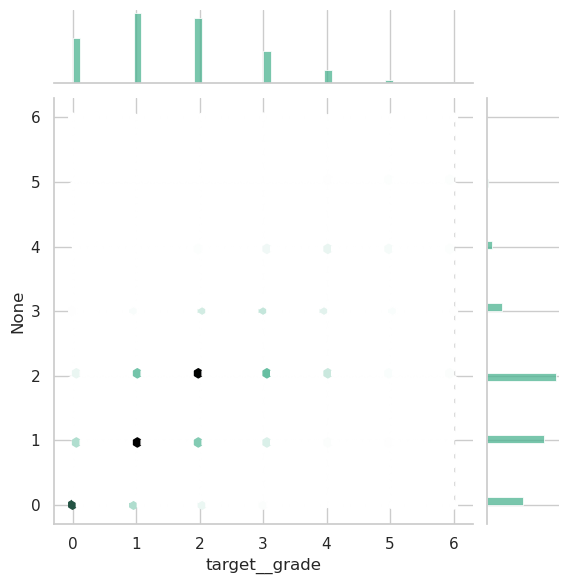

[figure not shown]

[output not shown]

[figure not shown]

### Calculating Probability Thresholds

If we're using our binary classification model to assign grades to loans based on default probabilities we can't directly try to predict the grades from the source dataset.

Basically what we can do is to use the source dataset as a baseline and try to determine whether our model can outperform the method the Lending Club is using for determine grades, we'll try to maintain the same ratio of grades while trying to minimize the default risk for loans included in top grades (basically we want to make sure that's the spread of default risk between grades is maximized i.e. default risk for grade A is as close to 0% and for grade F as close to 100% as possible while also ensuring that the risk increased with continuously with grade)

### Limitations

Therefore, to provide a more accurate estimate and to figure out whether our model would actually be useful we'd need to incorporate the actual amounts received etc.

TODO: consider doing this (we'd just need to use the appropriate column from the df)